# MATH60633A – TP2

April, 2025

**Project 1: Asset Management**

## FROM HERE

### 2. In-sample uncertainty

```r
library(dplyr)
library(tidyr)
library(ggplot2)
library(mvtnorm)
library(MASS)
library(RiskPortfolios)
library(Matrix)
library(here)
library(fitHeavyTail)
library(gt)
library(tidyverse)
library(PerformanceAnalytics)

source(here('src','core_functions.R'))
source(here('src','core_functions_2.R'))

set.seed(1234)

load(here("data", "FTSE_const_rets.rda"))
print(rets[1:5, 1:5])
```

```
##                  AAL.L       ABF.L       ADM.L      ADN.L         AHT.L
## 2012-01-13  0.04110959 0.008043236  0.04085183 0.02539474  0.0004529226
## 2012-01-20  0.03481821 0.023049569  0.01080860 0.05267915  0.0275531582
## 2012-01-27  0.01447372 0.016464347  0.03601586 0.03977470  0.0460779167
## 2012-02-03  0.07837651 0.007672054  0.12764789 0.03907901  0.0686151075
## 2012-02-10 -0.05618526 0.008460698 -0.07129170 0.03167222 -0.0261592195
```

#### 2.1 Gaussian model

This section first investigate the impact of parameter uncertainty in the in-sample performance using a Gaussian model calibrated on the data. The table below presents 95% confidence intervals computed via Gaussian bootstrap simulations (B=1000) for two portfolio strategies: minvol and maxdiv.

Starting with the mean, the maxdiv portfolio exhibits a 95% confidence interval ranging from approximately 0.127% to 0.575% per week, with a median value of 0.361%. In contrast, the minvol portfolio shows an expected return with a CI of 0.134% to 0.542%, and a median of 0.337%. Although the minvol return is lower on average, the intervals for both portfolios do overlap somewhat, suggesting that the difference in returns may not be statistically significant depending on the context and risk preferences.

Regarding volatility, the maxdiv portfolio is associated with a CI between 1.32% and 1.67%, and a median of 1.50%, whereas the minvol portfolio shows lower distribution of risk, with volatility bounded between 1.20% and 1.46%, and a median of 1.33%. This result aligns with the fundamental objective of each strategy: minvol is designed to reduce risk exposure, and this is clearly reflected in its tighter and lower volatility estimates.

Overall, these Gaussian bootstrap-based confidence intervals suggest that both portfolios are expected to deliver positive returns and Sharpe ratios, but with differing risk-return tradeoffs. The maxdiv strategy tends to achieve higher average returns but also comes with higher and more variable risk, while the minvol strategy offers more stable, lower-risk performance with comparable risk-adjusted returns.

```r
B_sim <- 1000

# Gaussian model
results_gauss <- run_bootstrap_simulation(rets, model_type = "gaussian", B = B_sim)
```

```
## [1] "Model: gaussian - Sim: 100 / 1000"
## [1] "Model: gaussian - Sim: 200 / 1000"
## [1] "Model: gaussian - Sim: 300 / 1000"
## [1] "Model: gaussian - Sim: 400 / 1000"
## [1] "Model: gaussian - Sim: 500 / 1000"
## [1] "Model: gaussian - Sim: 600 / 1000"
## [1] "Model: gaussian - Sim: 700 / 1000"
## [1] "Model: gaussian - Sim: 800 / 1000"
## [1] "Model: gaussian - Sim: 900 / 1000"
## [1] "Model: gaussian - Sim: 1000 / 1000"
```

```r
quant_gauss <- results_gauss %>%                             # original wide data
  dplyr::select(portfolio, mean, vol, sharpe) %>%     # keep the 3 metrics
  tidyr::pivot_longer(-portfolio,                            # long format
                      names_to  = "metric",
                      values_to = "value") %>%
  dplyr::group_by(portfolio, metric) %>%                     # group by BOTH
  dplyr::summarise(                                          # three required quantiles
    q025 = quantile(value, 0.025, na.rm = TRUE),
    q500 = quantile(value, 0.500, na.rm = TRUE),   # median
    q975 = quantile(value, 0.975, na.rm = TRUE),
    .groups = "drop"
  )

print(quant_gauss)
```

```
## # A tibble: 6 × 5
##   portfolio metric    q025    q500    q975
##   <chr>     <chr>    <dbl>   <dbl>   <dbl>
## 1 maxdiv    mean   0.00127 0.00361 0.00575
## 2 maxdiv    sharpe 0.0869  0.241   0.386
## 3 maxdiv    vol    0.0132  0.0150  0.0167
## 4 minvol    mean   0.00134 0.00337 0.00542
## 5 minvol    sharpe 0.0991  0.251   0.416
## 6 minvol    vol    0.0120  0.0133  0.0146
```

```r
calculate_portfolio_se <- function(results_df) {
  results_df %>%
    filter(complete.cases(mean, vol, sharpe)) %>%
    group_by(portfolio) %>%
    summarise(
      across(c(mean, vol, sharpe),
             list(mean = ~mean(.x, na.rm = TRUE), se = ~sd(.x, na.rm = TRUE))),
      n_sim_valid = n(),
      .groups = "drop"
    ) %>%
    rename_with(~gsub("_mean", "_avg", .x), contains("_mean"))
}

summary_gauss <- calculate_portfolio_se(results_gauss)

print("Gaussian Model Summary")
```

```
## [1] "Gaussian Model Summary"
```

```r
print(summary_gauss)
```

```
## # A tibble: 2 × 8
##   portfolio mean_avg mean_se vol_avg   vol_se sharpe_avg sharpe_se n_sim_valid
##   <chr>        <dbl>   <dbl>   <dbl>    <dbl>      <dbl>     <dbl>       <int>
## 1 maxdiv     0.00361 0.00113  0.0150 0.000876      0.241    0.0772        1000
## 2 minvol     0.00336 0.00103  0.0134 0.000677      0.253    0.0790        1000
```

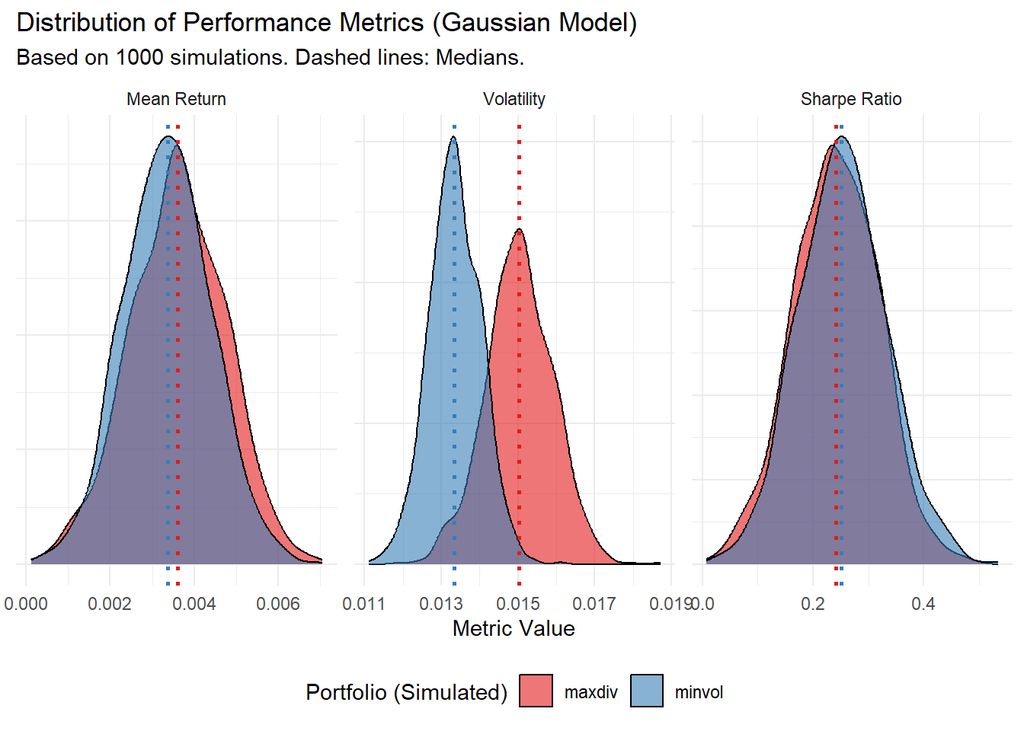

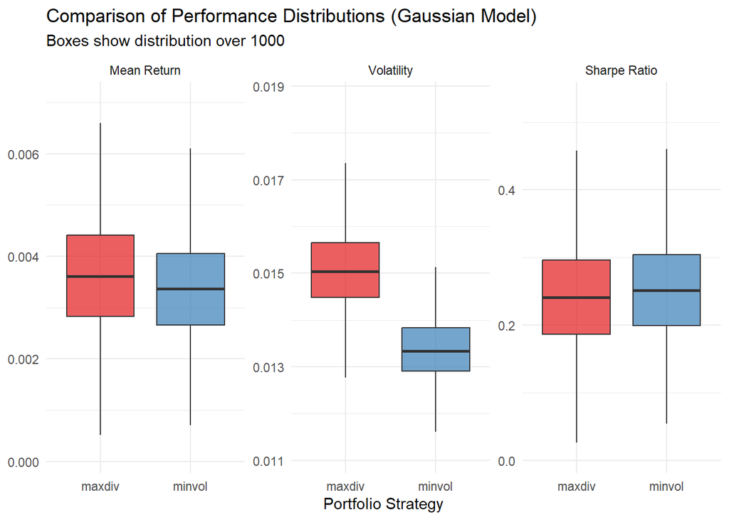

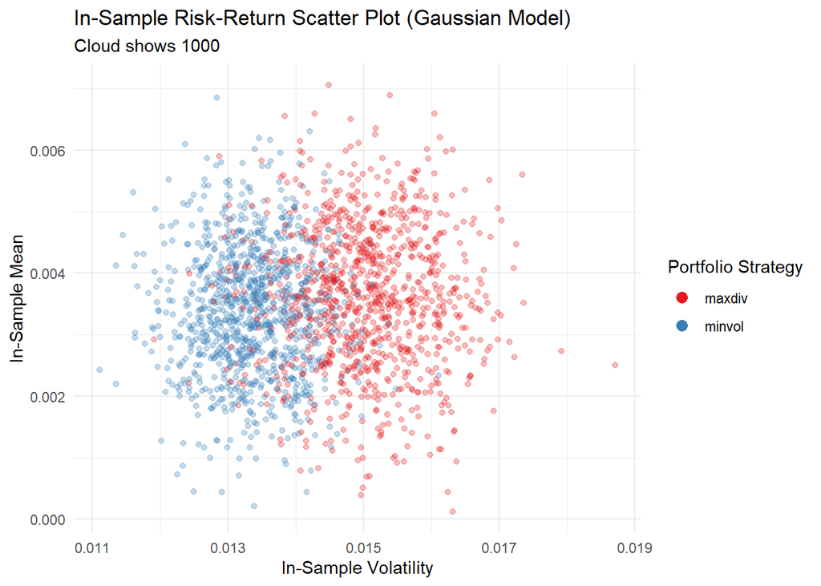

```r
if (exists("results_gauss") && is.data.frame(results_gauss) && nrow(results_gauss) > 0) {

  # Reshape Gaussian results
  results_long_gauss <- results_gauss %>%
    dplyr::select(portfolio, mean, vol, sharpe) %>%
    dplyr::filter(complete.cases(mean, vol, sharpe)) %>%
    tidyr::pivot_longer(cols = c(mean, vol, sharpe),
                        names_to = "metric",
                        values_to = "value") %>%
    dplyr::mutate(metric = factor(metric, levels = c("mean", "vol", "sharpe"),
                                  labels = c("Mean Return", "Volatility", "Sharpe Ratio")))

  if (nrow(results_long_gauss) > 0) {
    # Density Plots (Gaussian)
    plot_title_density_g <- "Distribution of Performance Metrics (Gaussian Model)"
    plot_subtitle_density_g <- paste("Based on", B_sim, "simulations. Dashed lines: Medians.")

    med_gauss <- results_long_gauss %>%                # already long format
    dplyr::group_by(portfolio, metric) %>%           # both facets
    dplyr::summarise(med = median(value, na.rm = TRUE),
                   .groups = "drop")

    # Density plot + dotted median line
    p1_g <- ggplot(results_long_gauss, aes(x = value, fill = portfolio)) +
      geom_density(alpha = 0.6) +
      facet_wrap(~ metric, scales = "free") +

      geom_vline(data = med_gauss,
                 aes(xintercept = med, colour = portfolio),
                 linetype = "dotted", size = 1,
                 inherit.aes = FALSE) +

      scale_fill_brewer(palette = "Set1",
                        name = "Portfolio (Simulated)") +
      scale_colour_brewer(palette = "Set1", guide = "none") +
      labs(title    = plot_title_density_g,
           subtitle = plot_subtitle_density_g,
           x = "Metric Value", y = "Density") +
      theme_minimal() +
      theme(legend.position = "bottom",
            axis.title.y = element_blank(),
            axis.text.y  = element_blank(),
            axis.ticks.y = element_blank() )

    print(p1_g)

    # Box Plots (Gaussian)
    plot_title_boxplot_g <- "Comparison of Performance Distributions (Gaussian Model)"
    plot_subtitle_boxplot_g <- paste("Boxes show distribution over", B_sim)

    p3_g <- ggplot(results_long_gauss, aes(x = portfolio, y = value, fill = portfolio)) +
      geom_boxplot(alpha = 0.7, outlier.shape = NA) +
      facet_wrap(~ metric, scales = "free_y") +
      scale_fill_brewer(palette = "Set1") +
      labs(title = plot_title_boxplot_g, subtitle = plot_subtitle_boxplot_g,
           x = "Portfolio Strategy", y = "Metric Value") +
      theme_minimal() +
      theme(legend.position = "none", axis.title.y = element_blank())
    print(p3_g)

  } else {
    warning("No valid Gaussian data remaining after filtering/pivoting for density/box plots.", call. = FALSE)
  } # End check for results_long_gauss


  # Scatter Plot (Gaussian)
  plot_title_scatter_g <- "In-Sample Risk-Return Scatter Plot (Gaussian Model)"
  plot_subtitle_scatter_g <- paste("Cloud shows", B_sim)

  scatter_data_g <- results_gauss %>% filter(complete.cases(vol, mean))
  if(nrow(scatter_data_g) > 0) {
    p2_g <- ggplot(scatter_data_g, aes(x = vol, y = mean, color = portfolio)) +
      geom_point(alpha = 0.3, size = 1.5) + # Simulation cloud
      scale_color_brewer(palette = "Set1", name = "Portfolio Strategy") +
      labs(title = plot_title_scatter_g, subtitle = plot_subtitle_scatter_g,
           x = "In-Sample Volatility", y = "In-Sample Mean") +
      theme_minimal() +
      guides(color = guide_legend(override.aes = list(alpha = 1, size = 3)))
    print(p2_g)
  }

}
```

#### 2.2 Student-t model

This subsections considers the same approach as in subsection 2.1 but with a Student-t model. The table displays the 95% bootstrap confidence intervals for the mean return, volatility, and Sharpe ratio under the Student-t model, across two portfolios: maxdiv and minvol. Starting with the mean, the maxdiv portfolio shows a 95% confidence interval ranging from approximately 0.040% to 0.533% per week, with a median of 0.300%. For the minvol strategy, the interval is tighter and lower, from 0.031% to 0.487%, with a median of 0.268%. These results suggest that, even under the Student-t model, the maxdiv strategy is expected to yield slightly higher returns on average, although the distributions are relatively close.

Comparing the Gaussian and Student-t bootstrap results reveals several important insights about how distributional assumptions affect perceived performance. The Student-t model consistently yields wider and more conservative confidence intervals. The comparison between the two models shows how distributional assumptions materially affect performance evaluation. Across all metrics, the Student-t model delivers more conservative estimates, especially for mean return and Sharpe ratio. This reflects the Student-t’s ability to capture heavy tails, thereby accounting for rare but impactful extreme events. In contrast, the Gaussian model, by assuming thin tails, overstates average performance and compresses confidence interval.

```r
B_sim <- 1000

# Student-t Model
results_t <- run_bootstrap_simulation(rets, model_type = "student_t",
                                      B = B_sim, seed = 456)
```

```
## [1] "Model: student_t - Sim: 100 / 1000"
## [1] "Model: student_t - Sim: 200 / 1000"
## [1] "Model: student_t - Sim: 300 / 1000"
## [1] "Model: student_t - Sim: 400 / 1000"
## [1] "Model: student_t - Sim: 500 / 1000"
## [1] "Model: student_t - Sim: 600 / 1000"
## [1] "Model: student_t - Sim: 700 / 1000"
## [1] "Model: student_t - Sim: 800 / 1000"
## [1] "Model: student_t - Sim: 900 / 1000"
## [1] "Model: student_t - Sim: 1000 / 1000"
```

```r
quant_t <- results_t %>%                             # original wide data
  dplyr::select(portfolio, mean, vol, sharpe) %>%     # keep the 3 metrics
  tidyr::pivot_longer(-portfolio,                            # long format
                      names_to  = "metric",
                      values_to = "value") %>%
  dplyr::group_by(portfolio, metric) %>%                     # group by BOTH
  dplyr::summarise(                                          # three required quantiles
    q025 = quantile(value, 0.025, na.rm = TRUE),
    q500 = quantile(value, 0.500, na.rm = TRUE),   # median
    q975 = quantile(value, 0.975, na.rm = TRUE),
    .groups = "drop"
  )

print(quant_t)
```

```
## # A tibble: 6 × 5
##   portfolio metric     q025    q500    q975
##   <chr>     <chr>     <dbl>   <dbl>   <dbl>
## 1 maxdiv    mean   0.000404 0.00300 0.00534
## 2 maxdiv    sharpe 0.0236   0.179   0.332
## 3 maxdiv    vol    0.0145   0.0167  0.0194
## 4 minvol    mean   0.000310 0.00268 0.00487
## 5 minvol    sharpe 0.0195   0.175   0.336
## 6 minvol    vol    0.0133   0.0152  0.0174
```

```r
calculate_portfolio_se <- function(results_df) {
  results_df %>%
    filter(complete.cases(mean, vol, sharpe)) %>%
    group_by(portfolio) %>%
    summarise(
      across(c(mean, vol, sharpe),
             list(mean = ~mean(.x, na.rm = TRUE), se = ~sd(.x, na.rm = TRUE))),
      n_sim_valid = n(),
      .groups = "drop"
    ) %>%
    rename_with(~gsub("_mean", "_avg", .x), contains("_mean"))
}

summary_t <- calculate_portfolio_se(results_t)

print("Studen-t Model Summary")
```

```
## [1] "Studen-t Model Summary"
```

```r
print(summary_t)
```

```
## # A tibble: 2 × 8
##   portfolio mean_avg mean_se vol_avg  vol_se sharpe_avg sharpe_se n_sim_valid
##   <chr>        <dbl>   <dbl>   <dbl>   <dbl>      <dbl>     <dbl>       <int>
## 1 maxdiv     0.00299 0.00127  0.0168 0.00124      0.179    0.0775        1000
## 2 minvol     0.00267 0.00117  0.0152 0.00103      0.176    0.0790        1000
```

[figure not shown]

[figure not shown]

[figure not shown]

```r
if (!exists("estimated_nu")) {
     # Attempt to calculate it now if 'rets' is available
     if(exists("rets") && requireNamespace("fitHeavyTail", quietly=TRUE)) {
        fit_t_check <- tryCatch(fitHeavyTail::fit_mvt(na.omit(rets)), error = function(e) NULL)
        if (!is.null(fit_t_check) && !is.null(fit_t_check$nu)) {
           estimated_nu <- round(fit_t_check$nu, 2)
           message(paste("Calculated estimated_nu for subtitle:", estimated_nu))
        } else { estimated_nu <- NA }
     } else { estimated_nu <- NA }
}
nu_subtitle_part <- ifelse(is.na(estimated_nu) || is.null(estimated_nu), "(nu not found)", paste("Est. nu =", estimated_nu))


if (exists("results_t") && is.data.frame(results_t) && nrow(results_t) > 0) {
  # Reshape Student-t results
  results_long_t <- results_t %>%
    dplyr::select(portfolio, mean, vol, sharpe) %>%
    dplyr::filter(complete.cases(mean, vol, sharpe)) %>%
    tidyr::pivot_longer(cols = c(mean, vol, sharpe),
                        names_to = "metric",
                        values_to = "value") %>%
    dplyr::mutate(metric = factor(metric, levels = c("mean", "vol", "sharpe"),
                                  labels = c("Mean Return", "Volatility", "Sharpe Ratio")))

  if (nrow(results_long_t) > 0) {
    # Density Plots (Student-t)
    plot_title_density_t <- "Distribution of Performance Metrics (d=50, Student-t Model)"
    plot_subtitle_density_t <- paste("Based on", B_sim, "simulations.", nu_subtitle_part, ". Dashed lines are original point estimates.")

    med_t <- results_long_t %>%                # already long format
    dplyr::group_by(portfolio, metric) %>%           # both facets
    dplyr::summarise(med = median(value, na.rm = TRUE),
                   .groups = "drop")

    # Density plot + dotted median line
    p1_t <- ggplot(results_long_t, aes(x = value, fill = portfolio)) +
      geom_density(alpha = 0.6) +
      facet_wrap(~ metric, scales = "free") +

      geom_vline(data = med_t,
                 aes(xintercept = med, colour = portfolio),
                 linetype = "dotted", size = 1,
                 inherit.aes = FALSE) +

      scale_fill_brewer(palette = "Set1",
                        name = "Portfolio (Simulated)") +
      scale_colour_brewer(palette = "Set1", guide = "none") +
      labs(title    = plot_title_density_t,
           subtitle = plot_subtitle_density_t,
           x = "Metric Value", y = "Density") +
      theme_minimal() +
      theme(legend.position = "bottom",
            axis.title.y = element_blank(),
            axis.text.y  = element_blank(),
            axis.ticks.y = element_blank() )

    print(p1_t)

    #  Box Plots (Student-t)
    plot_title_boxplot_t <- "Comparison of Performance Distributions (d=50, Student-t Model)"
    plot_subtitle_boxplot_t <- paste("Boxes show distribution over", B_sim, "simulations.", nu_subtitle_part, ". Diamonds are original point estimates.")

    p3_t <- ggplot(results_long_t, aes(x = portfolio, y = value, fill = portfolio)) +
      geom_boxplot(alpha = 0.7, outlier.shape = NA) +
      facet_wrap(~ metric, scales = "free_y") +
      scale_fill_brewer(palette = "Set1") +
      labs(title = plot_title_boxplot_t, subtitle = plot_subtitle_boxplot_t,
           x = "Portfolio Strategy", y = "Metric Value") +
      theme_minimal() +
      theme(legend.position = "none", axis.title.y = element_blank())
    print(p3_t)

  }


  # --- Plot 2.2: Scatter Plot (Student-t) ---
  plot_title_scatter_t <- "In-Sample Risk-Return Scatter Plot (d=50, Student-t Model)"
  plot_subtitle_scatter_t <- paste("Cloud shows", B_sim, "simulations.", nu_subtitle_part, ". Diamonds are original point estimates.")

  scatter_data_t <- results_t %>% filter(complete.cases(vol, mean))
  if(nrow(scatter_data_t) > 0) {
    p2_t <- ggplot(scatter_data_t, aes(x = vol, y = mean, color = portfolio)) +
      geom_point(alpha = 0.3, size = 1.5) + # Simulation cloud
      scale_color_brewer(palette = "Set1", name = "Portfolio Strategy") +
      labs(title = plot_title_scatter_t, subtitle = plot_subtitle_scatter_t,
           x = "In-Sample Volatility", y = "In-Sample Mean") +
      theme_minimal() +
      guides(color = guide_legend(override.aes = list(alpha = 1, size = 3)))
    print(p2_t)
  }

}
```

#### 2.3 In-sample shrinkage approaches

We now analyse the impact of robustification techniques. In particular, we compare the results considering the sample covariance matrix agains the results using two alternative shrinkage estimators from the package RiskPortfolios: 1- Ledoit-Wolf estimator (see Ledoit and Wolf (2003)); 2- Factor analysis with a total of 3 factors (see Harman (1976)).

First, to provide a visualization about what these alternative estimators are doing, we plot three heatmaps, one for each of the covariance matrix estimator. These heatmaps consider the entire sample period and all 50 assets. The sample covariance matrix heatmap reveals a highly detailed and noisy structure, where the clustering patterns appear dense and full of minor variations. This reflects the fact that the sample covariance estimator uses only historical data without any form of regularization. While the heatmap retains all the empirical relationships, it also retains much of the noise, which can lead to unstable portfolio optimization results.

The Ledoit-Wolf covariance matrix heatmap, by contrast, exhibits smoother transitions and more structured block patterns. This estimator applies shrinkage toward a structured target, which reduces estimation error and enhances numerical stability. The heatmap visually reflects this improvement: the noise is visibly reduced, and asset clusters emerge. The result is a more stable and reliable covariance estimate, especially valuable in high-dimensional settings.

The factor covariance matrix heatmap shows an even more pronounced level of shrinkage and structure. Instead of estimating pairwise covariances directly, this approach models asset covariances via exposures to a small number of underlying factors. This structure implies that much of the correlation is being captured through common latent components, and idiosyncratic relationships are downweighted or ignored.

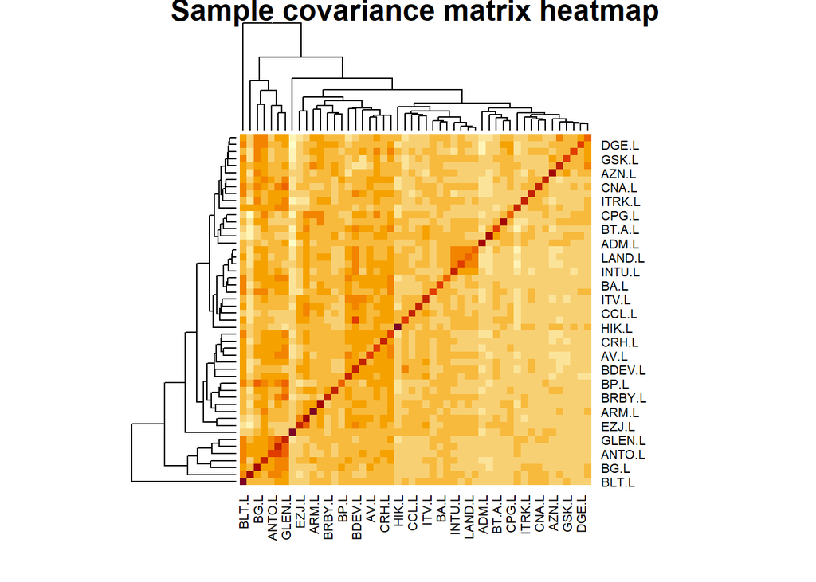

```r
heatmap(cov(rets),
        main = "Sample covariance matrix heatmap")
```

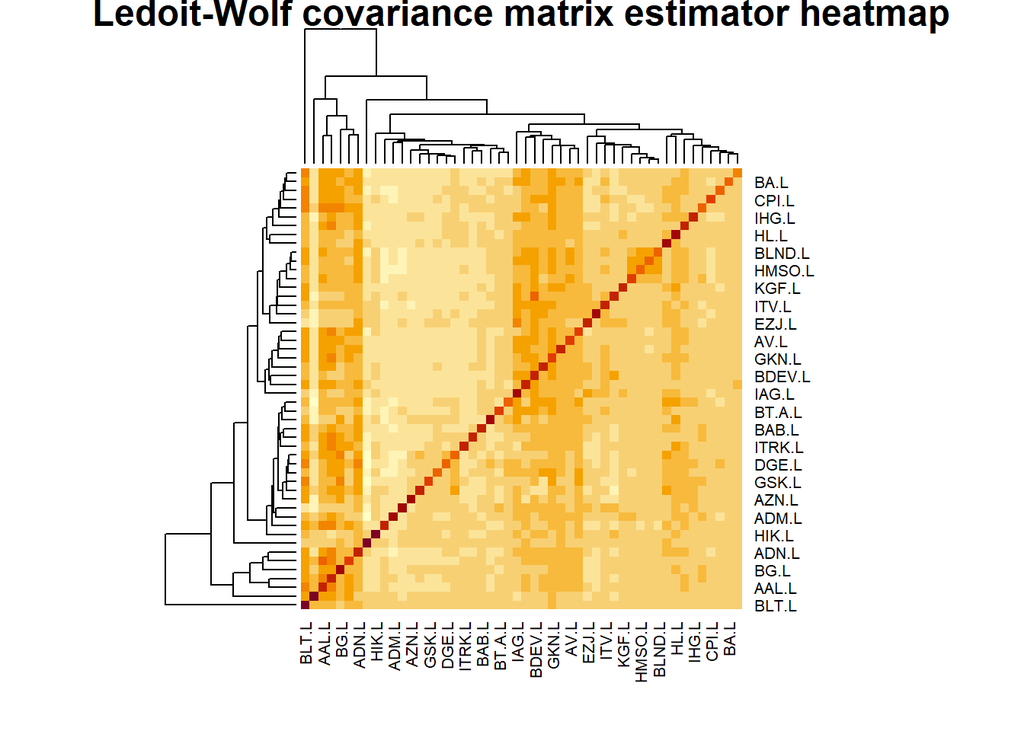

```r
heatmap(covEstimation(rets, control = list(type = 'lw')),
        main = "Ledoit-Wolf covariance matrix estimator heatmap")
```

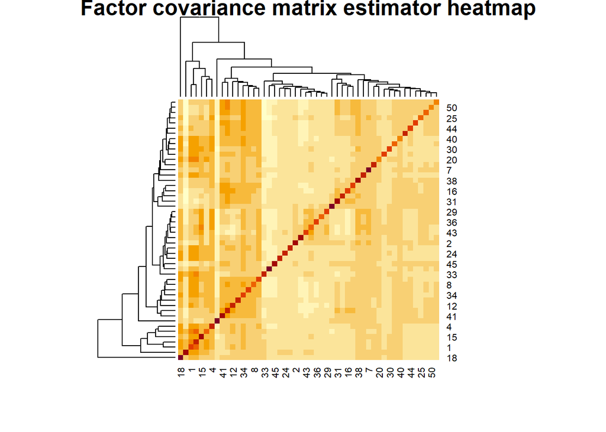

```r
heatmap(RiskPortfolios::covEstimation(rets, control = list(type = 'factor', K = 3)),
        main = "Factor covariance matrix estimator heatmap")
```

Importantly, for maxdiv, the LW estimator produces the lowest volatility on average, while the factor model stabilizes but with a slightly higher level. This may be due to the factor model ignoring some idiosyncratic variation. For minvol, the pattern is similar: sample covariance has more noise, LW delivers lower average volatility, and the factor model provides moderate stability.

These results reaffirm that shrinkage estimators improve stability, reducing the risk of overfitting and leading to more reliable portfolio construction, especially when asset dimensionality is high or the sample size is limited. We expect that these results should be even more pronounce when we consider out-of-sample results.

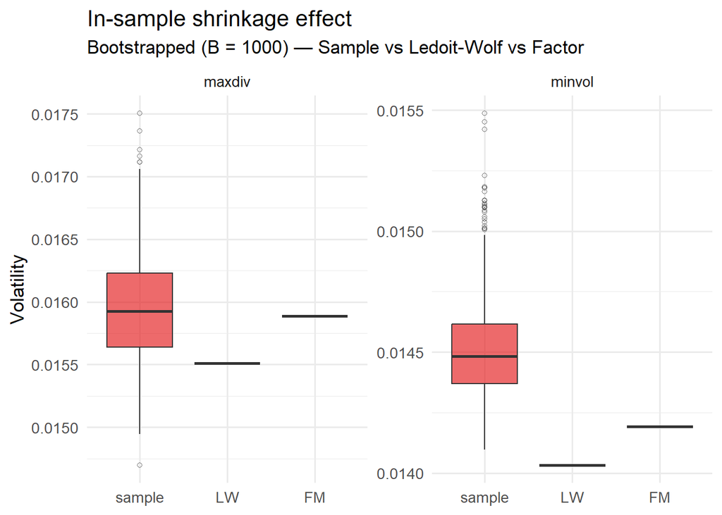

```r
B   <- 1000
res <- run_boot(rets, B)

summary_tab <- res |>
  group_by(portfolio, cov_est) |>
  summarise(across(c(mean, vol, SR),
                   list(mu = mean, se = sd), .names = "{.col}_{.fn}"),
            .groups = "drop")

ggplot(res, aes(x = cov_est, y = vol, fill = cov_est)) +
  geom_boxplot(alpha = .65, outlier.shape = 1) +
  facet_wrap(~ portfolio, scales = "free_y") +
  scale_fill_brewer(palette = "Set1", guide = "none") +
  labs(title = "In-sample shrinkage effect",
       subtitle = paste0("Bootstrapped (B = ", B, ") — Sample vs Ledoit-Wolf vs Factor"),
       x = NULL, y = "Volatility") +
  theme_minimal(base_size = 13)
```

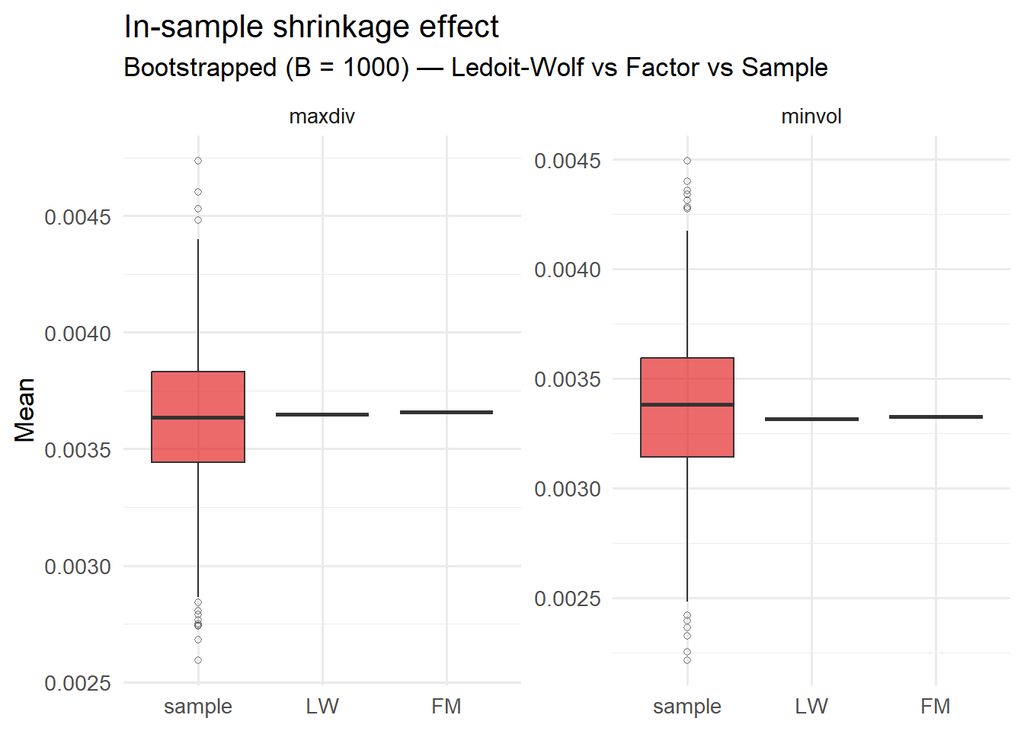

```r
ggplot(res, aes(x = cov_est, y = mean, fill = cov_est)) +
  geom_boxplot(alpha = .65, outlier.shape = 1) +
  facet_wrap(~ portfolio, scales = "free_y") +
  scale_fill_brewer(palette = "Set1", guide = "none") +
  labs(title = "In-sample shrinkage effect",
       subtitle = paste0("Bootstrapped (B = ", B, ") — Ledoit-Wolf vs Factor vs Sample"),
       x = NULL, y = "Mean") +
  theme_minimal(base_size = 13)
```

#### 2.4 Compare different resampling approaches

In this analysis, we explore how different resampling strategies impact the construction and stability of optimized portfolios when using the sample covariance matrix estimator. We consider three resampling schemes. First, the iid bootstrap, which resamples rows independently with replacement. Second, the block bootstrap, which resamples consecutive blocks of returns to preserve dependence. In this method, we consider the approach Politis and Romano (1994) and use the package tseries with option type of stationarity. Finally, the third method is Gaussian resampling, which generates synthetic returns from a multivariate normal distribution calibrated to the sample mean and covariance.

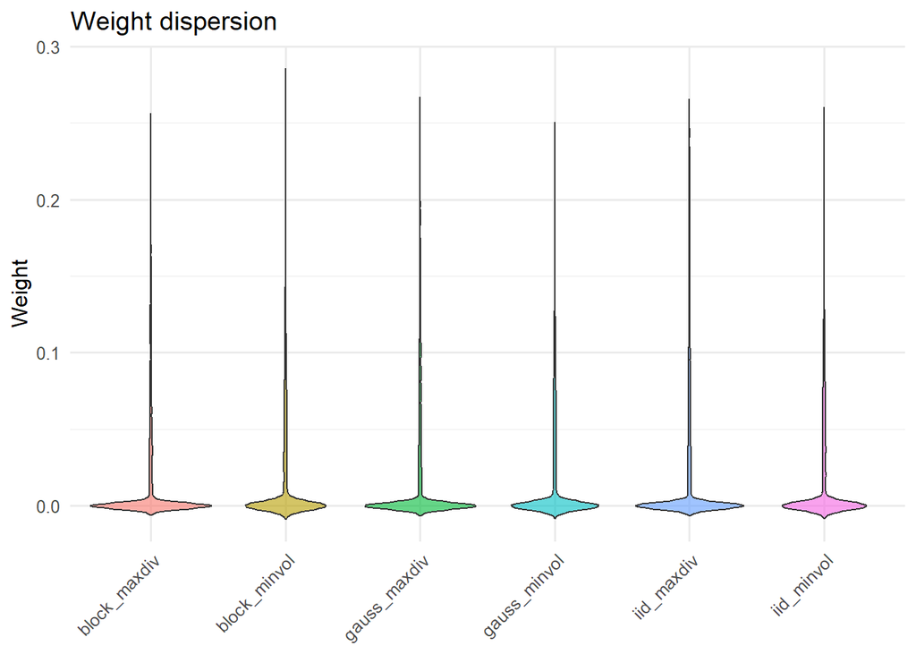

```r
boot_out <- boot_portfolio_stats(rets, B = 200)

w_long <- purrr::imap_dfr(boot_out$weights_raw, ~
                            as.data.frame(.x) |>
                            pivot_longer(everything(), values_to = "w") |>
                            mutate(tag = .y))

metric_long <- dplyr::bind_rows(boot_out$metrics_raw) |>
  pivot_longer(c(mean, vol, sharpe),
               names_to = "stat",
               values_to = "value")


p_weights <- ggplot(w_long, aes(tag, w, fill = tag)) +
  geom_violin(trim = FALSE, alpha = .6) +
  labs(title = "Weight dispersion", x = NULL, y = "Weight") +
  theme_minimal(base_size = 12) +
  theme(axis.text.x = element_text(angle = 45, hjust = 1),
        legend.position = "none")

p_metrics <- ggplot(metric_long, aes(tag, value, fill = tag)) +
  geom_violin(trim = FALSE, alpha = .6) +
  facet_wrap(~ stat, scales = "free_y") +
  labs(title = "Dispersion of mean, volatility, Sharpe",
       x = NULL, y = NULL) +
  theme_minimal(base_size = 12) +
  theme(axis.text.x = element_text(angle = 45, hjust = 1),
        legend.position = "none")

p_weights
```

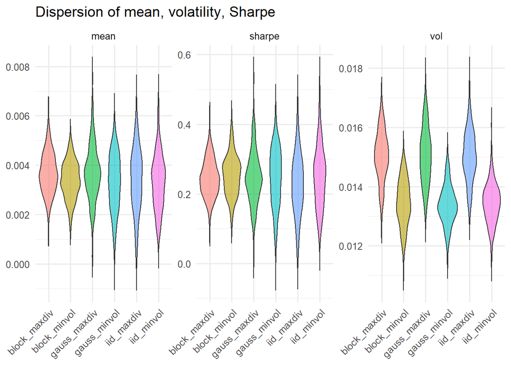

```r
p_metrics
```

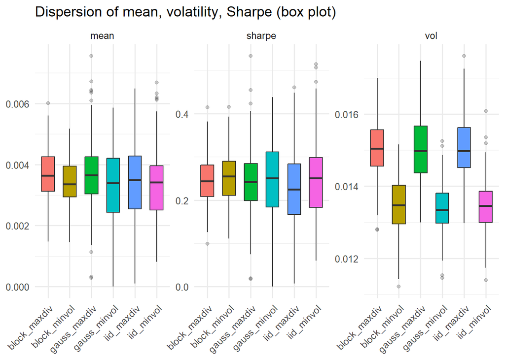

```r
p_metrics_box <- ggplot(metric_long, aes(tag, value, fill = tag)) +
  geom_boxplot(outlier.alpha = .25, width = .6) +
  facet_wrap(~ stat, scales = "free_y") +
  labs(title = "Dispersion of mean, volatility, Sharpe (box plot)",
       x = NULL, y = NULL) +
  theme_minimal(base_size = 12) +
  theme(axis.text.x = element_text(angle = 45, hjust = 1),
        legend.position = "none")

p_metrics_box
```